# Project 2

## KNN Models both Full Model and Specific Variable

```r
library(class)
library(gmodels)
for (kval in 5:25) {
  online_pred <- knn(train = online_training, test = online_test, cl=online_trainLabels, k=kval)
  onlinePREDCross <- CrossTable(online_testLabels, online_pred, prop.chisq = FALSE)
  print( paste("k = ", kval) )
  onlinePREDCross
  library(caret)
  cm = confusionMatrix(online_pred, reference = online_testLabels )
  cmaccu = cm$overall['Accuracy']
  print( paste("Total Accuracy = ", cmaccu ) )

  cmt = data.frame(k=kval, Total.Accuracy = cmaccu, row.names = NULL )
  ResultDf = rbind(ResultDf, cmt)
  print( xkabledply(   as.matrix(cm), title = paste("ConfusionMatrix for k = ",kval ) ) )
  print( xkabledply(data.frame(cm$byClass), title=paste("k = ",kval)) )
}
```

```r
# Selected Variable Model
for (kval in 10:30) {
  online_pred_selected <- knn(train = online_training_selected, test = online_test_selected, cl=online_trainLabels_selected, k=kval)
  onlinePREDCross_selected <- CrossTable(online_testLabels_selected, online_pred_selected, prop.chisq = FALSE)
  print( paste("k = ", kval) )
  onlinePREDCross_selected

  cm_selected = confusionMatrix(online_pred_selected, reference = online_testLabels_selected )
  cmaccu_selected = cm_selected$overall['Accuracy']
  print( paste("Total Accuracy = ", cmaccu_selected ) )

  cmt_selected = data.frame(k=kval, Total.Accuracy = cmaccu_selected, row.names = NULL )
  ResultDf_selected = rbind(ResultDf_selected, cmt_selected)
  print( xkabledply(   as.matrix(cm_selected), title = paste("ConfusionMatrix for k = ",kval ) ) )
  print( xkabledply(data.frame(cm_selected$byClass), title=paste("k = ",kval)) )
}
```

```r
xkabledply(ResultDf, "Total Accuracy Summary - Full Model KNN")
```

Total Accuracy Summary - Full Model KNN

| k | Total.Accuracy |
| --- | --- |
| 5 | 0.861 |
| 6 | 0.860 |
| 7 | 0.863 |
| 8 | 0.862 |
| 9 | 0.862 |
| 10 | 0.862 |
| 11 | 0.863 |
| 12 | 0.862 |
| 13 | 0.865 |
| 14 | 0.864 |
| 15 | 0.867 |
| 16 | 0.865 |
| 17 | 0.867 |
| 18 | 0.867 |
| 19 | 0.867 |
| 20 | 0.868 |
| 21 | 0.865 |
| 22 | 0.865 |
| 23 | 0.867 |
| 24 | 0.865 |
| 25 | 0.866 |

```r
# Selected Variable Model
xkabledply(ResultDf_selected, "Total Accuracy Summary - Selective Variable Model KNN")
```

Total Accuracy Summary - Selective Variable Model KNN

| k | Total.Accuracy |
| --- | --- |
| 10 | 0.887 |
| 11 | 0.886 |
| 12 | 0.887 |
| 13 | 0.885 |
| 14 | 0.884 |
| 15 | 0.886 |
| 16 | 0.883 |
| 17 | 0.886 |
| 18 | 0.887 |
| 19 | 0.887 |
| 20 | 0.887 |
| 21 | 0.887 |
| 22 | 0.888 |
| 23 | 0.885 |
| 24 | 0.885 |
| 25 | 0.887 |
| 26 | 0.888 |
| 27 | 0.886 |
| 28 | 0.887 |
| 29 | 0.887 |
| 30 | 0.884 |

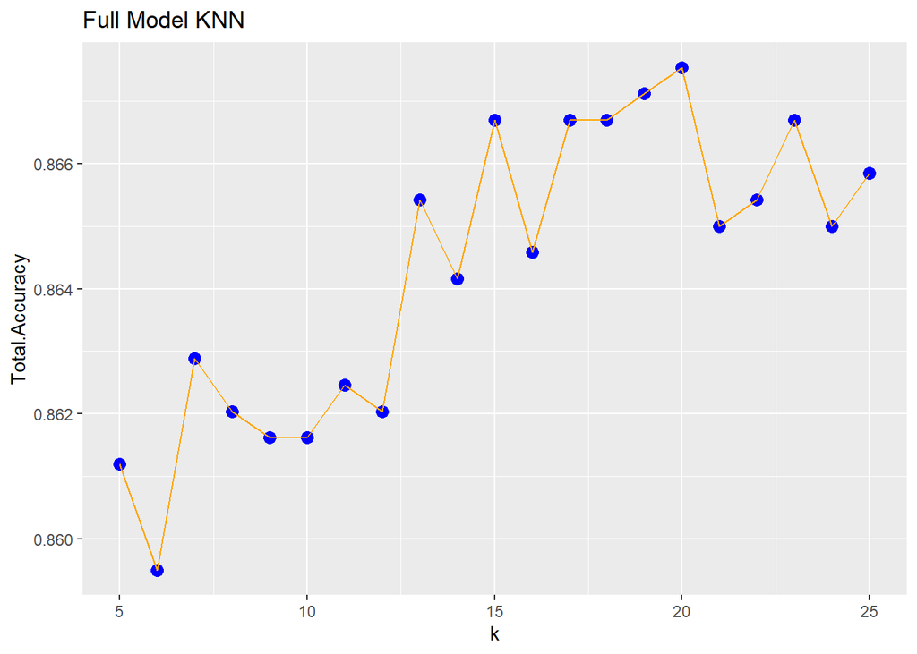

```r
kPlot = ggplot(ResultDf, aes(k, Total.Accuracy)) + geom_point(colour = "blue", size = 3) + geom_line(color='orange') + labs(title = "Full Model KNN")
kPlot
```

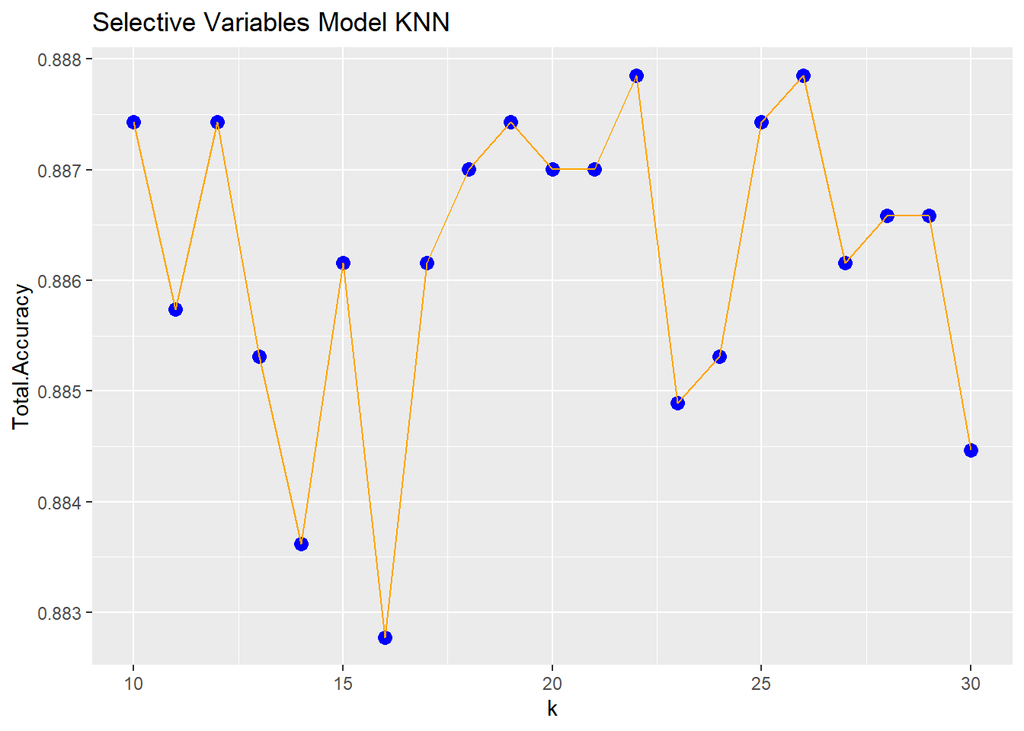

```r
kPlot_selected = ggplot(ResultDf_selected, aes(k, Total.Accuracy)) + geom_point(colour = "blue", size = 3) + geom_line(color='orange') + labs(title = "Selective Variables Model KNN")
kPlot_selected
```

It is easy to see that after we implement both K-Nearest Neighbor models one being the full model and the other being a model using selected x variables that we have a bit higher accuracy with the selective variable model. The accuracy plots above gives us the best k to accuracy. When we look at the output of the models with all the different k values you can see that accuracy is important but for our dataset so is specificity with the balance issue of yes to no ratio in revenue.

```r
# Max Accuracy
online_pred_max <- knn(train = online_training, test = online_test, cl=online_trainLabels, k=15)
onlinePREDCross_max <- CrossTable(online_testLabels, online_pred, prop.chisq = FALSE)
# Selected Variable Model
online_pred_max_selected <- knn(train = online_training_selected, test = online_test_selected, cl=online_trainLabels_selected, k=25)
onlinePREDCross_max_selected <- CrossTable(online_testLabels_selected, online_pred_selected, prop.chisq = FALSE)
```

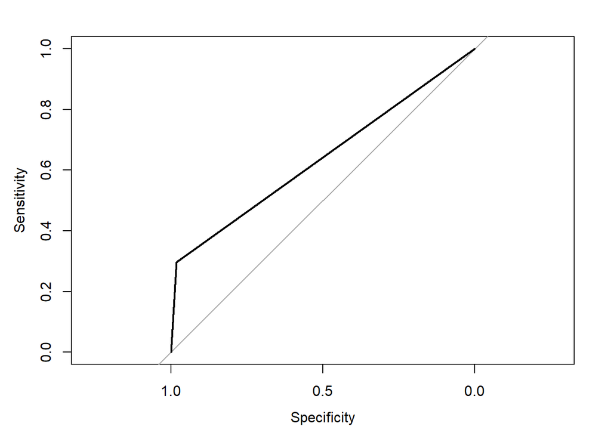

```r
loadPkg("pROC")
# model with every variable
h <- roc(online_testLabels , as.integer(online_pred_max))
auc(h)
plot(h)
```

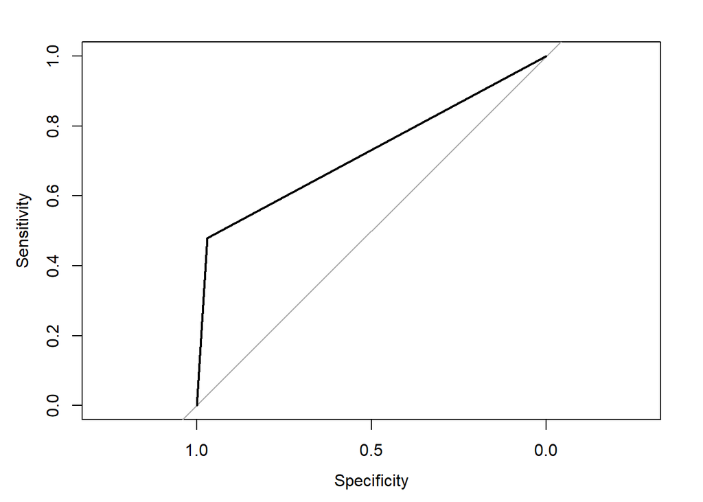

```r
# model with specific variables
h_selected <- roc(online_testLabels_selected , as.integer(online_pred_max_selected))
auc(h_selected)
plot(h_selected)
```

Sadly, both models do not meet the cut off AUC metric of 0.8. We can see from the Confusion Matrix that when the models are at the optimal k value the total accuracy are in the high 80 percent levels. However, the issue we need to address is the specificity that is measured by taking the true negatives divided by the true negatives plus the false positives. For both models we built we can see that there are small specificity rates.

## Concluding Remarks

In the end, we found that our models all had strengths and weaknesses in their approaches. Due to our use of cross-validation and proper training/testing splits, our results were consistent throughout multiple splits. Still, the problem mainly rested on balancing between specificity and sensitivity in our models, due to the unbalanced dataset. In that manner, our models were not all consistently producing a smooth ROC curve that maxmimized AUC, our metric of interest. Out of our final models, the logistic regression scored the highest AUC, with a very smooth curve, and the classification tree and K-NN models stood a bit below, and ran into the most problems with the unbalanced dataset. Going forward, more time-series information or even more observations would be helpful to balance the dataset and give more insight into the relationships between the covariates and `Revenue`.

## Citations

Sakar, C. O., Polat, S. O., Katircioglu, M., & Kastro, Y. (2018, May 9). Real-time prediction of online shoppers’ purchasing intention using Multilayer Perceptron and LSTM recurrent neural networks - neural computing and applications. SpringerLink. Retrieved November 16, 2022, from https://link.springer.com/article/10.1007/s00521-018-3523-0